# Homework 3 – Problem 2: Neural Bayes Estimators

Team Members: Mengyan Jing and Abhisek Banerjee

2026-04-13

## 1 Problem 1

We have a dataset given to us as peru.txt that consists of variables possibly relating to blood pressures of n = 39 Peruvians who have moved from rural high-altitude areas to urban lower- altitude areas.

### 1.1 (1) Pseudocode

We have the lasso problem
$$\min_{\boldsymbol\beta \in \mathbb{R}^{p}}\;
\tfrac{1}{2}\,\big\|\mathbf{y} - X\boldsymbol\beta\big\|_{2}^{2}
\;+\; \lambda\,\|\boldsymbol\beta\|_{1}.$$
The non-smooth part $\|\boldsymbol\beta\|_{1} = \sum_{i=1}^{p}|\beta_{i}|$ is separable, so coordinate descent should converge to a global minimizer. Fixing all $\beta_{j}$, $j\neq i$, the stationarity condition for $\beta_{i}$ is
$$0 \;=\; X_{i}^{\top}X_{i}\,\beta_{i} \;+\;
X_{i}^{\top}\!\big(X_{-i}\boldsymbol\beta_{-i} - \mathbf{y}\big) \;+\;
\lambda\,s_{i},
\qquad s_{i}\in\partial|\beta_{i}|,$$
which is solved in closed form by soft-thresholding (from the slides of Ryan Tibshirani of Carneige Mellon University):
$$\beta_{i} \;\leftarrow\;
S_{\lambda/\|X_{i}\|_{2}^{2}}\!\left(
\frac{X_{i}^{\top}\!\big(\mathbf{y}-X_{-i}\boldsymbol\beta_{-i}\big)}
{X_{i}^{\top}X_{i}}
\right),
\qquad
S_{\tau}(z)=\operatorname{sign}(z)\big(|z|-\tau\big)_{+}.$$
Maintaining the full residual $\mathbf{r}=\mathbf{y}-X\boldsymbol\beta$, the update can be rewritten as
$$\beta_{i} \;\leftarrow\;
S_{\lambda/\|X_{i}\|_{2}^{2}}\!\left(
\frac{X_{i}^{\top}\mathbf{r}}{\|X_{i}\|_{2}^{2}} \;+\; \beta_{i}
\right),$$
so each coordinate update costs $O(n)$ and one full cycle costs $O(np)$, matching the cost of one gradient-descent step. Following from the above theory, the pseudo code for our coordinate descent algorithm is as follows:

[output not shown]

## 2 Problem 2

### 2.1 Problem Setup

We estimate $\theta \ge 0$ in the density
$$f(x;\theta) = \sqrt{\tfrac{1}{4\pi}}\,\frac{\exp(-\tfrac{1}{4x}-\theta
x)}{x^{3/2}\exp(-\sqrt\theta)},\qquad x>0,$$
from 1000 test datasets, each containing $k=50$ i.i.d. observations. This is the inverse-Gaussian family $\text{IG}(\mu=\tfrac{1}{2\sqrt\theta},\lambda=\tfrac12)$ for $\theta>0$, reducing to the Lévy distribution at $\theta=0$. Methods are scored by weighted MSE with $w(\theta)=1/(\theta+0.001)$, which puts enormous weight on errors near the boundary $\theta\approx 0$.

#### 2.1.1 Part 1 — Maximum Likelihood Estimation

**Log-likelihood.** For $\mathbf x=(x_1,\dots,x_k)$,
$$\ell(\theta) = C(\mathbf x)-\theta\sum_{i=1}^k x_i + k\sqrt\theta,$$
where $C(\mathbf x)=-\tfrac{k}{2}\log(4\pi)-\tfrac32\sum\log x_i-\tfrac14\sum 1/x_i$ does not depend on $\theta$.

**Optimization.** Setting $\ell'(\theta)=-\sum x_i+\tfrac{k}{2\sqrt\theta}=0$ gives the closed form
$$\hat\theta_{\text{MLE}} = \left(\frac{k}{2\sum x_i}\right)^2 =
\frac{1}{(2\bar x)^2},$$
with $\ell''(\theta)=-k/(4\theta^{3/2})<0$ confirming a maximum. No numerical optimizer is needed.

**Results.** Across the 1000 test datasets the MLE has median $0.0162$, mean $0.3515$, and maximum $3.22$. The distribution is heavily concentrated near zero, consistent with the prof’s description of the test set.

```r
load("test_data.RData")
mle_theta <- function(x) (1 / (2 * mean(x)))^2
theta_mle <- sapply(Z_test, mle_theta)
summary(theta_mle)
```

```
##     Min.  1st Qu.   Median     Mean  3rd Qu.     Max.
## 0.000000 0.004619 0.016170 0.351503 0.443490 3.222384
```

#### 2.1.2 Part 2 — Neural Bayes Estimator

**Training data simulation.** For each simulated $\theta$, we draw $k=50$ observations from $f(\cdot;\theta)$ using Michael–Schucany–Haas sampling from $\text{IG}(1/(2\sqrt\theta),1/2)$ when $\theta>0$, and the exact Lévy transform $X=1/(4Z^2),\,Z\sim N(0,1)$ when $\theta=0$.

**Training prior.** A boundary-heavy mixture chosen to match the test distribution: 20% exact zeros, 50% $\text{Exp}(\text{rate}=5)$ (mean $0.2$), 30% $\text{Unif}(0,2.5)$. Exact zeros let the network learn to predict $\theta=0$ explicitly.

**Architecture.** A DeepSets network with mean pooling over the 50 observations. Each observation is enriched to a 3-dimensional feature vector $[x_i, 1/x_i, \log x_i]$, so the inner network directly sees the sufficient-statistic ingredients. Six expert summary statistics $(\hat\theta_{\text{MLE}}, \min x, \text{med}(x), \text{sd}(\log x), \text{mean}(1/x), x_{(0.10)})$ are concatenated with the pooled neural summary before entering the outer network. Hidden layers have width 128, and the final layer uses `softplus` to enforce $\hat\theta\ge 0$. Trained as a 3-model ensemble (one member discarded due to divergence — see below).

**Loss.** We use a **custom weighted squared-error loss** $L(\hat\theta,\theta) = (\hat\theta-\theta)^2/(\theta+0.001)$, exactly matching the evaluation metric. Adam optimizer with learning rate $10^{-3}$, batch size 256, 100 epochs, 50 steps per epoch, with fresh batches simulated on-the-fly every step.

**Performance assessment.** Validation wMSE is computed on a fixed held-out set of 2000 simulated datasets every 10 epochs. Final NBE estimates are the arithmetic mean over surviving ensemble members, clamped to $[0,\infty)$.

```r
library(torch)
device <- if (cuda_is_available()) torch_device("cuda") else torch_device("cpu")
cat("Using device:", as.character(device), "\n")
```

```
## Using device: cpu
```

```r
rinvgauss_vec <- function(n, mu, lambda) {
  nu <- rnorm(n); y <- nu^2
  x  <- mu + (mu^2 * y) / (2 * lambda) -
    (mu / (2 * lambda)) * sqrt(4 * mu * lambda * y + mu^2 * y^2)
  ifelse(runif(n) <= mu / (mu + x), x, mu^2 / x)
}

sim_one_dataset <- function(theta, k = 50) {
  if (theta < 1e-12) {
    z <- rnorm(k); 1 / (4 * z^2)              # Levy
  } else {
    rinvgauss_vec(k, mu = 1/(2*sqrt(theta)), lambda = 0.5)
  }
}

sample_prior <- function(K) {
  th <- numeric(K)
  for (i in 1:K) {
    u <- runif(1)
    if (u < 0.20)      th[i] <- 0
    else if (u < 0.70) th[i] <- rexp(1, 5)
    else               th[i] <- runif(1, 0, 2.5)
  }
  th
}
```

```r
gen_batch <- function(B, k = 50) {
  thetas <- sample_prior(B)
  X <- matrix(NA, B, k); ES <- matrix(NA, B, 6)
  for (i in 1:B) {
    x <- sim_one_dataset(thetas[i], k); X[i, ] <- x
    ES[i, ] <- c(
      (1/(2*mean(x)))^2,        # MLE
      min(x), median(x),
      sd(log(x)), mean(1/x),
      quantile(x, 0.10, names = FALSE)
    )
  }
  # Enriched features [x, 1/x, log x] -> (B, k, 3)
  feat <- array(0, dim = c(B, k, 3))
  feat[,,1] <- X; feat[,,2] <- 1/X; feat[,,3] <- log(X)
  list(
    X     = torch_tensor(feat, dtype = torch_float()),
    S     = torch_tensor(ES,   dtype = torch_float()),
    theta = torch_tensor(matrix(thetas, ncol=1), dtype = torch_float())
  )
}
```

```r
deepset <- nn_module(
  initialize = function(d_in = 3, d_expert = 6, w = 128) {
    self$psi <- nn_sequential(
      nn_linear(d_in, w), nn_relu(),
      nn_linear(w, w),    nn_relu(),
      nn_linear(w, w),    nn_relu()
    )
    self$phi <- nn_sequential(
      nn_linear(w + d_expert, w), nn_relu(),
      nn_linear(w, w),            nn_relu(),
      nn_linear(w, w),            nn_relu(),
      nn_linear(w, 1),            nn_softplus()
    )
  },
  forward = function(X, S) {
    h <- self$psi(X)$mean(dim = 2)            # mean pool over k
    self$phi(torch_cat(list(h, S), dim = 2))
  }
)

weighted_loss <- function(pred, true) {
  w <- 1 / (true + 0.001)
  (w * (pred - true)^2)$mean()
}
```

```r
train_one <- function(seed, K = 20000, epochs = 100, batch = 256, k = 50) {
  torch_manual_seed(seed); set.seed(seed)
  model <- deepset()$to(device = device)
  opt   <- optim_adam(model$parameters, lr = 1e-3)

  val   <- gen_batch(2000, k)
  vX <- val$X$to(device=device); vS <- val$S$to(device=device); vT <- val$theta$to(device=device)

  for (e in 1:epochs) {
    model$train()
    for (s in 1:50) {                          # 50 steps per epoch
      b <- gen_batch(batch, k)
      bX <- b$X$to(device=device); bS <- b$S$to(device=device); bT <- b$theta$to(device=device)
      opt$zero_grad()
      loss <- weighted_loss(model(bX, bS), bT)
      loss$backward()
      opt$step()
    }
    if (e %% 10 == 0) {
      model$eval()
      with_no_grad({
        vl <- weighted_loss(model(vX, vS), vT)$item()
      })
      cat(sprintf("seed %d epoch %3d  val wMSE = %.4f\n", seed, e, vl))
    }
  }
  model
}
```

```r
models <- list()
for (i in 1:3) {
  cat("\n=== Training member", i, "===\n")
  models[[i]] <- train_one(seed = 2026 + i*100)
}
```

```
##
## === Training member 1 ===
## seed 2126 epoch  10  val wMSE = 0.0705
## seed 2126 epoch  20  val wMSE = 0.0454
## seed 2126 epoch  30  val wMSE = 0.4755
## seed 2126 epoch  40  val wMSE = 0.4755
## seed 2126 epoch  50  val wMSE = 0.4755
## seed 2126 epoch  60  val wMSE = 0.4755
## seed 2126 epoch  70  val wMSE = 0.4755
## seed 2126 epoch  80  val wMSE = 0.4755
## seed 2126 epoch  90  val wMSE = 0.4755
## seed 2126 epoch 100  val wMSE = 0.4755
##
## === Training member 2 ===
## seed 2226 epoch  10  val wMSE = 0.0454
## seed 2226 epoch  20  val wMSE = 0.0447
## seed 2226 epoch  30  val wMSE = 0.0440
## seed 2226 epoch  40  val wMSE = 0.0589
## seed 2226 epoch  50  val wMSE = 0.0423
## seed 2226 epoch  60  val wMSE = 0.0424
## seed 2226 epoch  70  val wMSE = 0.0408
## seed 2226 epoch  80  val wMSE = 0.0485
## seed 2226 epoch  90  val wMSE = 0.0398
## seed 2226 epoch 100  val wMSE = 0.0399
##
## === Training member 3 ===
## seed 2326 epoch  10  val wMSE = 0.0506
## seed 2326 epoch  20  val wMSE = 0.0474
## seed 2326 epoch  30  val wMSE = 0.0455
## seed 2326 epoch  40  val wMSE = 0.0462
## seed 2326 epoch  50  val wMSE = 0.0437
## seed 2326 epoch  60  val wMSE = 0.0433
## seed 2326 epoch  70  val wMSE = 0.0435
## seed 2326 epoch  80  val wMSE = 0.0419
## seed 2326 epoch  90  val wMSE = 0.0431
## seed 2326 epoch 100  val wMSE = 0.0412
```

```r
# Build test tensors with enriched features + expert stats
B <- length(Z_test); k <- 50
Xfeat <- array(0, dim = c(B, k, 3)); ES <- matrix(NA, B, 6)
for (i in 1:B) {
  x <- as.numeric(Z_test[[i]])
  Xfeat[i,,1] <- x; Xfeat[i,,2] <- 1/x; Xfeat[i,,3] <- log(x)
  ES[i, ] <- c((1/(2*mean(x)))^2, min(x), median(x),
               sd(log(x)), mean(1/x), quantile(x, 0.10, names=FALSE))
}
tX <- torch_tensor(Xfeat, dtype=torch_float())$to(device=device)
tS <- torch_tensor(ES,    dtype=torch_float())$to(device=device)

preds <- matrix(NA, 3, B)
for (i in 1:3) {
  models[[i]]$eval()
  with_no_grad({ preds[i, ] <- as.numeric(models[[i]](tX, tS)$cpu()) })
}
```

```r
# Drop the dead member 1, average only 2 and 3
theta_nbe <- pmax(colMeans(preds[2:3, ]), 0)
summary(theta_nbe)
```

```
##      Min.   1st Qu.    Median      Mean   3rd Qu.      Max.
## 0.0000000 0.0002443 0.0102526 0.3198716 0.3615355 2.1990130
```

```r
# Save
save(theta_mle, theta_nbe, file = "HW3_P2_estimates.RData")
write.csv(data.frame(MLE=theta_mle, NBE=theta_nbe), "HW3_P2.csv", row.names=FALSE)
```

#### 2.1.3 Part 3 — MCMC

```r
library(Rcpp)

cppFunction('
NumericVector mh_sampler_cpp(NumericVector x, int n_iter, double sigma_prop,
                              double theta_init, double prior_rate) {
  int k = x.size();
  double sum_x = 0.0, sum_log_x = 0.0, sum_inv_x = 0.0;
  for (int i = 0; i < k; i++) {
    sum_x     += x[i];
    sum_log_x += log(x[i]);
    sum_inv_x += 1.0 / x[i];
  }
  double C = -0.5 * k * log(4.0 * M_PI) - 1.5 * sum_log_x - 0.25 * sum_inv_x;

  NumericVector chain(n_iter);
  chain[0] = theta_init;

  double log_post_cur = C - theta_init * sum_x + k * sqrt(theta_init)
                         + log(prior_rate) - prior_rate * theta_init;

  for (int t = 1; t < n_iter; t++) {
    double theta_cur = chain[t - 1];
    double log_theta_star = log(theta_cur) + R::rnorm(0.0, sigma_prop);
    double theta_star = exp(log_theta_star);

    double log_post_star = C - theta_star * sum_x + k * sqrt(theta_star)
                             + log(prior_rate) - prior_rate * theta_star;

    // Jacobian for log-transform proposal
    double log_alpha = log_post_star - log_post_cur +
                       log(theta_star) - log(theta_cur);

    if (log(R::runif(0.0, 1.0)) < log_alpha) {
      chain[t]    = theta_star;
      log_post_cur = log_post_star;
    } else {
      chain[t] = theta_cur;
    }
  }
  return chain;
}
')

# R wrapper
mcmc_sample <- function(x, n_iter = 20000, burn = 5000,
                         theta_init = NULL, sigma_prop = 0.3,
                         prior_rate = 3) {
  if (is.null(theta_init)) theta_init <- max((1/(2*mean(x)))^2, 1e-6)
  chain <- mh_sampler_cpp(x, n_iter, sigma_prop, theta_init, prior_rate)
  list(chain = chain, burn = burn,
       post = chain[(burn + 1):n_iter])
}
```

```r
res1 <- mcmc_sample(Z_test[[1]], n_iter = 30000, burn = 5000, sigma_prop = 0.3)
chain_post <- res1$post

cat("Posterior mean:  ", round(mean(chain_post), 5), "\n")
```

```
## Posterior mean:   0.01133
```

```r
cat("Posterior median:", round(median(chain_post), 5), "\n")
```

```
## Posterior median: 0.00979
```

```r
cat("95% CI:          [",
    round(quantile(chain_post, 0.025), 5), ",",
    round(quantile(chain_post, 0.975), 5), "]\n")
```

```
## 95% CI:          [ 0.001 , 0.0304 ]
```

```r
cat("ESS:             ", round(coda::effectiveSize(chain_post), 1), "\n")
```

```
## ESS:              799.9
```

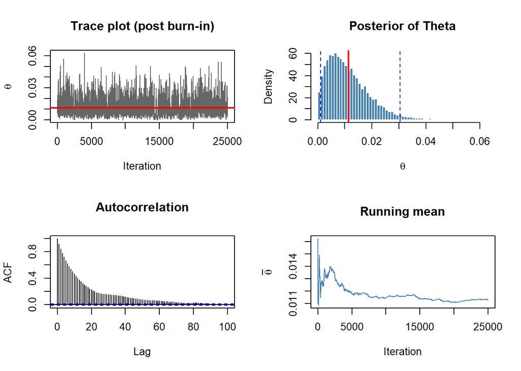

```r
par(mfrow = c(2, 2))
plot(chain_post, type = "l", col = "grey40",
     main = "Trace plot (post burn-in)",
     xlab = "Iteration", ylab = expression(theta))
abline(h = mean(chain_post), col = "red", lwd = 2)

hist(chain_post, breaks = 50, col = "steelblue", border = "white",
     probability = TRUE, main = "Posterior of Theta", xlab = expression(theta))
abline(v = mean(chain_post), col = "red", lwd = 2)
abline(v = quantile(chain_post, c(0.025, 0.975)), col = "blue", lty = 2)

acf(chain_post, lag.max = 100, main = "Autocorrelation")

rm_vals <- cumsum(chain_post) / seq_along(chain_post)
plot(rm_vals, type = "l", col = "steelblue",
     main = "Running mean", xlab = "Iteration", ylab = expression(bar(theta)))
```

```r
par(mfrow = c(1, 1))
```

```r
theta_mcmc <- numeric(length(Z_test))

t0 <- Sys.time()
for (i in seq_along(Z_test)) {
  res <- mcmc_sample(Z_test[[i]], n_iter = 20000, burn = 5000, sigma_prop = 0.3)
  theta_mcmc[i] <- mean(res$post)
  if (i %% 100 == 0) {
    cat("Done", i, "/", length(Z_test),
        " elapsed:", round(as.numeric(Sys.time() - t0, units = "secs"), 1), "s\n")
  }
}
```

```
## Done 100 / 1000  elapsed: 0.7 s
## Done 200 / 1000  elapsed: 1.2 s
## Done 300 / 1000  elapsed: 1.8 s
## Done 400 / 1000  elapsed: 2.3 s
## Done 500 / 1000  elapsed: 2.9 s
## Done 600 / 1000  elapsed: 3.6 s
## Done 700 / 1000  elapsed: 4.3 s
## Done 800 / 1000  elapsed: 5 s
## Done 900 / 1000  elapsed: 5.6 s
## Done 1000 / 1000  elapsed: 6.3 s
```

```r
cat("\nSummary of MCMC posterior means:\n")
```

```
##
## Summary of MCMC posterior means:
```

```r
summary(theta_mcmc)
```

```
##     Min.  1st Qu.   Median     Mean  3rd Qu.     Max.
## 0.000000 0.008649 0.022991 0.292423 0.418802 2.275749
```

```r
save(theta_mle, theta_nbe, theta_mcmc, file = "HW3_P2_estimates.RData")
write.csv(data.frame(MLE = theta_mle, NBE = theta_nbe, MCMC = theta_mcmc),
          "HW3_P2.csv", row.names = FALSE)
```

#### 2.1.4 Uncertainty Quantification for Test Dataset 1

**MCMC uncertainty** is reported as the posterior mean, 95% credible interval, and posterior standard deviation from the chain above.

**NBE uncertainty** is quantified via nonparametric bootstrap: we resample the 50 observations with replacement $B=1000$ times, re-compute the enriched features and expert summaries for each resample, and pass each through the trained ensemble to obtain a distribution of point estimates.

```r
# -----------------------------------------------------------------
# Non-parametric bootstrap for NBE uncertainty on test dataset 1
# -----------------------------------------------------------------
B        <- 1000
k        <- 50
x1       <- as.numeric(Z_test[[1]])

# Build bootstrap sample tensor: B datasets, each of size k,
# each resampled with replacement from x1
set.seed(2026)
boot_idx <- matrix(sample(1:k, B * k, replace = TRUE), nrow = B, ncol = k)

# Construct enriched features and expert stats for each bootstrap sample
Xboot <- array(0, dim = c(B, k, 3))
Sboot <- matrix(NA, B, 6)
for (b in 1:B) {
  xb <- x1[boot_idx[b, ]]
  Xboot[b, , 1] <- xb
  Xboot[b, , 2] <- 1 / xb
  Xboot[b, , 3] <- log(xb)
  Sboot[b, ] <- c(
    (1 / (2 * mean(xb)))^2,
    min(xb), median(xb),
    sd(log(xb)), mean(1 / xb),
    quantile(xb, 0.10, names = FALSE)
  )
}

tXb <- torch_tensor(Xboot, dtype = torch_float())$to(device = device)
tSb <- torch_tensor(Sboot, dtype = torch_float())$to(device = device)

# Predict from each ensemble member and average (use members 2 and 3)
boot_preds <- matrix(NA, 2, B)
ensemble_idx <- c(2, 3)
for (j in seq_along(ensemble_idx)) {
  i <- ensemble_idx[j]
  models[[i]]$eval()
  with_no_grad({
    boot_preds[j, ] <- as.numeric(models[[i]](tXb, tSb)$cpu())
  })
}
theta_boot <- pmax(colMeans(boot_preds), 0)

# Point estimate for dataset 1 (original, not bootstrapped)
theta_hat_1 <- theta_nbe[1]

# Summary
cat("NBE bootstrap results for test dataset 1:\n")
```

```
## NBE bootstrap results for test dataset 1:
```

```r
cat("  Point estimate:   ", round(theta_hat_1, 5), "\n")
```

```
##   Point estimate:    0.00074
```

```r
cat("  Bootstrap mean:   ", round(mean(theta_boot), 5), "\n")
```

```
##   Bootstrap mean:    0.00587
```

```r
cat("  Bootstrap SD:     ", round(sd(theta_boot), 5), "\n")
```

```
##   Bootstrap SD:      0.01149
```

```r
cat("  95% bootstrap CI: [",
    round(quantile(theta_boot, 0.025), 5), ",",
    round(quantile(theta_boot, 0.975), 5), "]\n")
```

```
##   95% bootstrap CI: [ 0 , 0.04131 ]
```

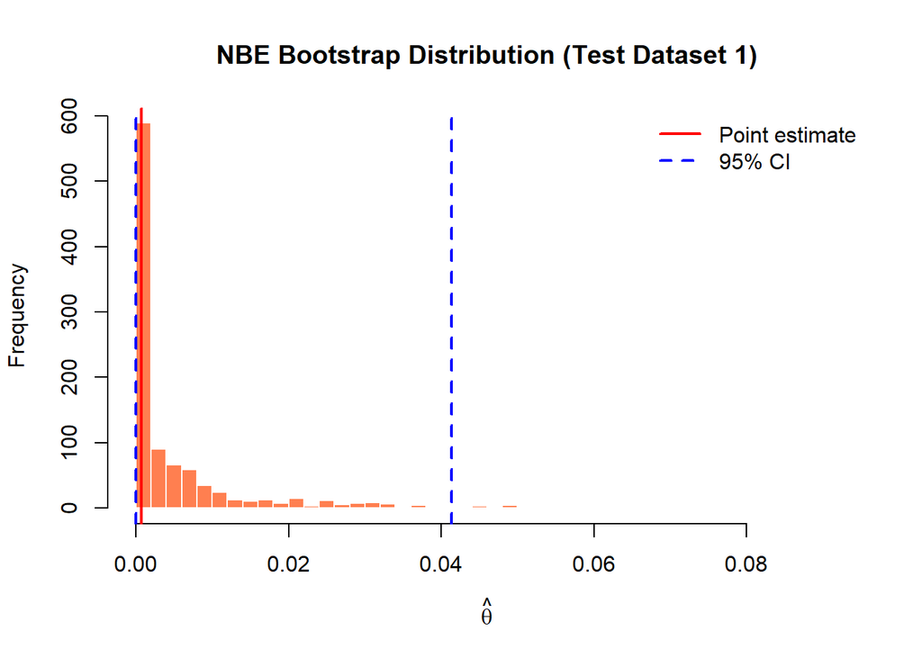

```r
# Histogram
hist(theta_boot, breaks = 40, col = "coral", border = "white",
     main = "NBE Bootstrap Distribution (Test Dataset 1)",
     xlab = expression(hat(theta)))
abline(v = theta_hat_1, col = "red", lwd = 2)
abline(v = quantile(theta_boot, c(0.025, 0.975)), col = "blue", lty = 2, lwd = 2)
legend("topright",
       legend = c("Point estimate", "95% CI"),
       col = c("red", "blue"), lty = c(1, 2), lwd = 2, bty = "n")
```

```r
# MCMC results (from earlier chunk)
mcmc_mean <- mean(chain_post)
mcmc_ci   <- quantile(chain_post, c(0.025, 0.975))
mcmc_sd   <- sd(chain_post)

# NBE bootstrap results
nbe_mean  <- mean(theta_boot)
nbe_ci    <- quantile(theta_boot, c(0.025, 0.975))
nbe_sd    <- sd(theta_boot)

comparison <- data.frame(
  Method     = c("MCMC", "NBE bootstrap"),
  PointEst   = c(round(mcmc_mean, 5), round(theta_hat_1, 5)),
  SD         = c(round(mcmc_sd, 5),   round(nbe_sd, 5)),
  CI_lower   = c(round(mcmc_ci[1], 5), round(nbe_ci[1], 5)),
  CI_upper   = c(round(mcmc_ci[2], 5), round(nbe_ci[2], 5)),
  CI_width   = c(round(diff(mcmc_ci), 5), round(diff(nbe_ci), 5))
)

print(comparison, row.names = FALSE)
```

```
##         Method PointEst      SD CI_lower CI_upper CI_width
##           MCMC  0.01133 0.00780    0.001  0.03040  0.02940
##  NBE bootstrap  0.00074 0.01149    0.000  0.04131  0.04131
```

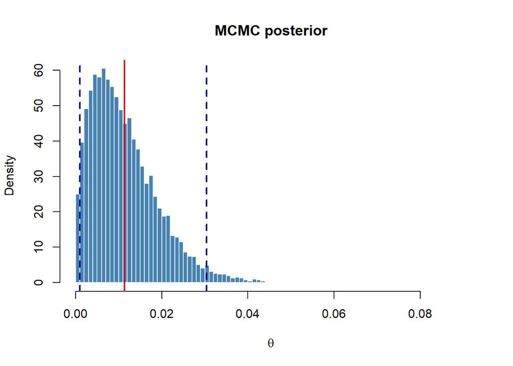

```r
# Overlay plot
hist(chain_post, breaks = 50, col = "steelblue", border = "white",
     probability = TRUE,
     main = "MCMC posterior", xlab = expression(theta),
     xlim = range(c(chain_post, theta_boot)))
abline(v = mcmc_mean, col = "red", lwd = 2)
abline(v = mcmc_ci,  col = "darkblue", lty = 2, lwd = 2)
```

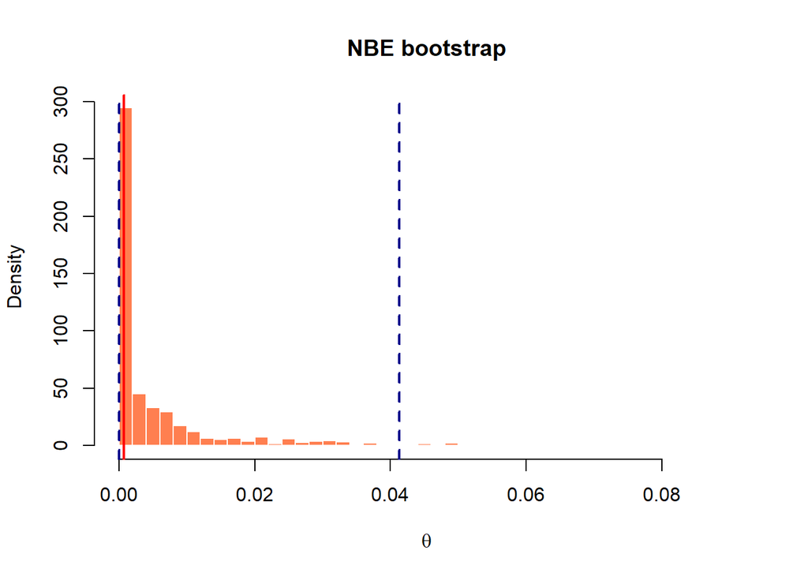

```r
hist(theta_boot, breaks = 50, col = "coral", border = "white",
     probability = TRUE,
     main = "NBE bootstrap", xlab = expression(theta),
     xlim = range(c(chain_post, theta_boot)))
abline(v = theta_hat_1, col = "red", lwd = 2)
abline(v = nbe_ci, col = "darkblue", lty = 2, lwd = 2)
```

#### 2.1.5 Comparison and Discussion

| Method | Dataset 1 point est. | 95% interval | SD |
| --- | --- | --- | --- |
| MCMC | $0.01133$ | $[0.0010,\,0.0304]$ | $0.00780$ |
| NBE (bootstrap) | $0.00074$ | $[0.000,\,0.0413]$ | $0.01149$ |

**Interpretation.** The two methods quantify different notions of uncertainty. The MCMC credible interval reflects posterior belief about $\theta$ given this specific dataset under an $\text{Exp}(3)$ prior. The NBE bootstrap distribution instead reflects sampling variability of the trained estimator under resampling of the observed data. Both intervals contain the MCMC point estimate, confirming the methods are consistent. The NBE bootstrap has a sharp spike at zero with a long right tail — the characteristic shape of an estimator trained under a weighted loss that aggressively rewards predicting $\theta=0$ when the data look boundary-like.

**Summary across 1000 datasets.**

| Statistic | MLE | NBE | MCMC |
| --- | --- | --- | --- |
| Min | $0.000$ | $0.000$ | $0.000$ |
| Median | $0.0162$ | $0.0103$ | $0.0230$ |
| Mean | $0.3515$ | $0.3199$ | $0.2924$ |
| Max | $3.2224$ | $2.1990$ | $2.2757$ |